# ejercicios

Vanessa

16/7/2021

```r
#2)
#a)
sum(1:1000)
```

```
## [1] 500500
```

```r
#b)
sum(2^(0:10))
```

```
## [1] 2047
```

```r
#3)
#a)
load(url("https://goo.gl/uDzU8v"))
grupo
```

```
##   [1] "B" "A" "E" "D" "B" "D" "D" "A" "D" "C" "D" "E" "B" "E" "E" "E" "A" "B"
##  [19] "C" "C" "A" "C" "C" "D" "D" "E" "E" "A" "B" "C" "C" "E" "D" "C" "E" "E"
##  [37] "E" "E" "D" "D" "D" "E" "E" "E" "D" "E" "B" "E" "D" "C" "E" "D" "E" "E"
##  [55] "C" "B" "D" "C" "E" "D" "E" "B" "D" "B" "B" "C" "D" "C" "C" "C" "E" "D"
##  [73] "E" "D" "C" "D" "E" "E" "C" "D" "C" "E" "D" "A" "B" "B" "E" "E" "C" "D"
##  [91] "C" "E" "E" "C" "E" "D" "D" "D" "E" "D" "A" "D" "B" "B" "C" "D" "E" "A"
## [109] "E" "E" "A" "C" "E" "D" "A" "D" "D" "C" "E" "E" "E" "D" "A" "E" "E" "E"
## [127] "C" "C" "B" "C" "C" "D" "C" "B" "C" "A" "D" "E" "D" "E" "E" "B" "E" "E"
## [145] "E" "E" "C" "B" "D" "D" "E" "E" "D" "D" "E" "D" "E" "D" "D" "C" "D" "D"
## [163] "D" "C" "E" "D" "E" "C" "E" "B" "C" "C" "C" "D" "D" "B" "D" "B" "E" "C"
## [181] "E" "D" "D" "E" "D" "B" "B" "E" "E" "A" "C" "A"
```

```r
length(grupo)
```

```
## [1] 192
```

```r
#b)
which(grupo == "A")
```

```
##  [1]   2   8  17  21  28  84 101 108 111 115 123 136 190 192
```

```r
#4)
#a)
nota
```

```
##   [1] 4.9 5.4 5.2 6.8 5.0 6.2 4.4 4.1 4.3 5.5 5.5 4.8 6.4 6.8 5.5 4.7 5.2 6.4
##  [19] 4.8 3.4 4.7 6.0 5.9 5.4 5.3 5.6 6.9 5.6 4.2 4.4 5.8 4.8 6.1 6.2 6.6 5.2
##  [37] 4.6 5.0 2.5 4.0 5.6 4.9 5.4 3.9 4.2 4.7 4.2 5.4 3.7 6.2 5.9 3.7 5.8 2.7
##  [55] 5.6 5.0 2.6 5.0 4.9 3.4 5.9 4.3 6.1 4.5 5.5 3.2 3.2 6.4 4.4 6.0 5.0 5.4
##  [73] 7.0 3.8 4.2 4.7 4.7 5.3 6.8 4.0 7.2 4.8 6.0 4.1 4.5 5.8 2.9 5.0 4.6 4.9
##  [91] 6.8 4.2 6.9 5.7 5.7 6.4 4.4 4.2 4.5 5.8 4.3 3.7 7.4 3.9 5.2 4.9 3.6 5.5
## [109] 6.0 5.0 4.1 4.5 3.1 5.4 4.5 5.3 4.7 6.1 5.2 7.7 5.3 5.0 4.0 5.2 4.0 5.5
## [127] 4.0 5.4 4.6 3.4 6.2 5.7 3.8 4.8 4.0 4.4 5.5 5.9 5.9 5.7 4.9 1.7 5.5 5.9
## [145] 5.5 3.8 5.5 6.0 3.5 5.5 7.5 3.4 5.8 4.7 3.6 4.1 5.0 4.6 3.6 4.7 4.1 5.7
## [163] 5.9 4.7 3.2 5.5 3.0 4.5 5.5 5.9 5.6 6.0 4.4 3.7 4.4 6.8 6.1 4.7 4.2 6.2
## [181] 5.2 5.1 2.9 6.5 4.2 5.4 5.9 6.2 6.3 4.8 5.6 2.9
```

```r
sum(nota)
```

```
## [1] 962
```

```r
#b)
mean(nota)
```

```
## [1] 5.010417
```

```r
#c)
which(nota>=7.0)
```

```
## [1]  73  81 103 120 151
```

```r
#d)
sort(nota, decreasing = T)
```

```
##   [1] 7.7 7.5 7.4 7.2 7.0 6.9 6.9 6.8 6.8 6.8 6.8 6.8 6.6 6.5 6.4 6.4 6.4 6.4
##  [19] 6.3 6.2 6.2 6.2 6.2 6.2 6.2 6.1 6.1 6.1 6.1 6.0 6.0 6.0 6.0 6.0 6.0 5.9
##  [37] 5.9 5.9 5.9 5.9 5.9 5.9 5.9 5.9 5.8 5.8 5.8 5.8 5.8 5.7 5.7 5.7 5.7 5.7
##  [55] 5.6 5.6 5.6 5.6 5.6 5.6 5.5 5.5 5.5 5.5 5.5 5.5 5.5 5.5 5.5 5.5 5.5 5.5
##  [73] 5.5 5.4 5.4 5.4 5.4 5.4 5.4 5.4 5.4 5.3 5.3 5.3 5.3 5.2 5.2 5.2 5.2 5.2
##  [91] 5.2 5.2 5.1 5.0 5.0 5.0 5.0 5.0 5.0 5.0 5.0 5.0 4.9 4.9 4.9 4.9 4.9 4.9
## [109] 4.8 4.8 4.8 4.8 4.8 4.8 4.7 4.7 4.7 4.7 4.7 4.7 4.7 4.7 4.7 4.7 4.6 4.6
## [127] 4.6 4.6 4.5 4.5 4.5 4.5 4.5 4.5 4.4 4.4 4.4 4.4 4.4 4.4 4.4 4.3 4.3 4.3
## [145] 4.2 4.2 4.2 4.2 4.2 4.2 4.2 4.2 4.1 4.1 4.1 4.1 4.1 4.0 4.0 4.0 4.0 4.0
## [163] 4.0 3.9 3.9 3.8 3.8 3.8 3.7 3.7 3.7 3.7 3.6 3.6 3.6 3.5 3.4 3.4 3.4 3.4
## [181] 3.2 3.2 3.2 3.1 3.0 2.9 2.9 2.9 2.7 2.6 2.5 1.7
```

```r
#e)
which(nota == max(nota))
```

```
## [1] 120
```

```r
#5)
#a)
sum(nota[1:10])
```

```
## [1] 51.8
```

```r
#b)
length(grupo[grupo=="C"])
```

```
## [1] 39
```

```r
#c)
length(nota[nota>=5])
```

```
## [1] 102
```

```r
#d)
length(nota[grupo == "B" & nota >= 5])
```

```
## [1] 12
```

```r
#e)
(length(nota[grupo == "C" & nota >= 5])/length(nota[grupo == "C"]))*100
```

```
## [1] 58.97436
```

```r
#f)
grupo[nota == max(nota)]
```

```
## [1] "E"
```

```r
grupo[nota == min(nota)]
```

```
## [1] "B"
```

```r
#g)
#library(dplyr)
notasEst <- dplyr::tibble(grupoAyB = grupo, notaAyB = nota)
notasEst %>%
  dplyr::filter((grupoAyB == "A" & notaAyB >=5) | (grupoAyB == "B" & notaAyB >= 5)) %>%
  dplyr::summarise(mean(notaAyB))
```

```
## # A tibble: 1 x 1
##   `mean(notaAyB)`
##             <dbl>
## 1            5.82
```

```r
#6)
#cuantil 66 de todos
quantile(nota, probs = 0.66)
```

```
## 66%
## 5.5
```

```r
#cuantil 66 del grupo'C' solamente"
quantile(nota[grupo=="C"], probs = 0.66)
```

```
##   66%
## 5.808
```

```r
#7) Un alumno tiene una nota de 4.9.
#¿Qué porcentaje, del total de alumnos, tiene una nota menor o igual que la suya?
((length(nota[nota <= 4.9]))/(length(nota)))*100
```

```
## [1] 46.875
```

```r
#¿Y qué porcentaje tiene una nota mayor o igual que la suya?
((length(nota[nota >= 4.9]))/(length(nota)))*100
```

```
## [1] 56.25
```

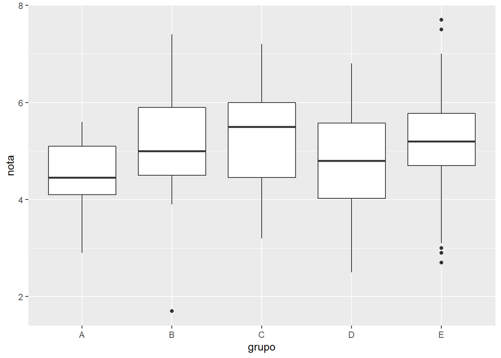

```r
#8) Realiza el gráfico de diagramas de caja de las notas de cada grupo,
#para poder comparar el nivel de cada uno de ellos.

#library(ggplot2)
notasEst <- dplyr::tibble(grupo, nota)
notasEst %>% ggplot(mapping = aes(x = grupo, y = nota)) +
  geom_boxplot()
```

```r
#9) Si la variable conc recoge la concentración de plomo (en ppm) en el aire de cierta zona durante un día completo
#a) ¿Cuál ha sido la concentración máxima?
load(url("https://goo.gl/uDzU8v"))
max(conc)
```

```
## [1] 47.34
```

```r
#b) ¿En cuántos de los muestreos se ha superado la concentración de 40.0 ppm?
length(conc[conc > 40])
```

```
## [1] 61
```

```r
#c) ¿Cuál ha sido la concentración media del día?
mean(conc)
```

```
## [1] 24.07229
```

```r
#d) ¿Cuáles fueron las 10 mediciones más bajas del día?
sort(conc)[1:10]
```

```
##  [1] 0.93 1.07 1.77 2.03 2.58 2.73 2.75 2.88 2.88 2.91
```

```r
#e) Si la primera medida fue a las 00:00. ¿A qué hora del día se alcanzó la concentración máxima?
fecha <- seq(
  as.POSIXct("2021-01-01 00:00"),
  length.out = length(conc),
  by = "5 min"
)

#concentracion de plomo y las fechas
concYfech <- data.frame(conc, fecha)
#maximo de concentracion con fecha
concYfech[conc == max(conc),]
```

```
##      conc               fecha
## 142 47.34 2021-01-01 11:45:00
```

**SEGUNDA PARTE**

#1) z<-matrix(c(1:10,(1:10)^2), nrow = 10) DF2 = as.data.frame((z), row.names= c(“eje_x”, “eje_y”)) View(DF2) ggplot(data = DF2) + geom_point(mapping = aes(x =V1 , y =V2), color = “blue”)

#2) #matrix(c(1,2,3,2,4,6,3,6,9,4,8,12), nrow = 4, byrow = T)

```r
#3)
#diag(x = 1,nrow = 3)
```

```r
#4)
matriz_cero <- function(val1,val2){
  resultado <- matrix(0, nrow = val1, ncol = val2)
  return(resultado)
}
matriz_cero(4,5)
```

```
##      [,1] [,2] [,3] [,4] [,5]
## [1,]    0    0    0    0    0
## [2,]    0    0    0    0    0
## [3,]    0    0    0    0    0
## [4,]    0    0    0    0    0
```

#5) diag(x = c(0,2,3,4),nrow = 4)

#6) matriz_A <- matrix(c(1,2,3,2,4,6,3,6,9,4,8,12), nrow = 4, byrow = T) t(matriz)

#7) #c) matriz_B <- diag(x = c(0,2,3,4),nrow = 4) 3*matriz_B #d)

#8) P = matrix(c(1,2,3,-2,4,-2,1,0,1), nrow = 3, byrow = T)

potencia <- function(x,k){ r <- diag(dim(x)[2]) for(i in 1:k){ r <- r%*%x } r } potencia(P,6)

#9) ecuaciones <- rbind(c(3, -1, 1), c(9, -2, 1), c(3, 1, -2)) equivalencias <- c(-1, -9, -9) solve(ecuaciones, equivalencias)

```r
#10)
#?eigen()
#?det()
```

#11) B <- matrix(c(1:10, seq(2, 20, by = 2), seq(3, 30, by = 3), seq(4, 40, by = 4), seq(5, 50, by = 5)), nrow = 10) A <- matrix(c(rep(c(0,1),7), rep(c(0,0,1),2),1,0,1,1,0), nrow = 5, byrow = T) (B)%*%(A)-(A)%*%t(B)

#12) x2 <- matrix(c(rep(1,5), 1, -1, 0:2), nrow = 5, byrow = F) y2 <- matrix(c(0,0,1,1,3), nrow = 5, byrow = F)

solve(t(x2)%*%x2)%*%t(x2)%*%y2

#13) data(“co2”) means = aggregate(co2, FUN=mean) year = as.vector(time(means)) co2 = as.vector(means) co2

df_co2 <- data.frame(year = year, co2 = co2) %>% mutate(co2_2 = lag(co2), dif_co2 = co2 - co2_2) vect_diferencia <- df_co2$dif_co2[2:39] vect_diferencia

plot(x = df_co2$year[2:39], y = vect_diferencia, xlab = “Año”, ylab = “Variación de CO2”, main = “Diferencia de CO2 & tiempo”, type = “o”, pch = 16, col=“green”)

plot(x = df_co2$year[2:39], y = vect_diferencia, xlab = “Años”, ylab = “Variación de CO2”, main = “Diferencia de CO2 & tiempo”, type = “o”, pch = 16, xlim = c(1960,2020), ylim = c(0,3)) points(2020, 2.64, pch = 4, col = “red”)